# store 101 customer style study

Luxiaoguang

2016年1月10日

## 获取数据

```
##   bask_id     bask_code cust_id cust_code store_id store_code
## 1  130801 130801NNN0001       0           20024001        101
## 2  130802 130802NNN0001       0           20024001        101
## 3  130803 130803NNN0001       0           20024001        101
## 4  130804 130804NNN0001       0           20024001        101
## 5  130805 130805NNN0001       0           20024001        101
## 6  130806 130806NNN0001       0           20024001        101
##         shop_datetime original_shop_datetime bask_spend bask_quantity
## 1 2013-08-01 00:00:00       01AUG13:00:00:00          0             0
## 2 2013-08-02 00:00:00       02AUG13:00:00:00          0             0
## 3 2013-08-03 00:00:00       03AUG13:00:00:00          0             0
## 4 2013-08-04 00:00:00       04AUG13:00:00:00          0             0
## 5 2013-08-05 00:00:00       05AUG13:00:00:00          0             0
## 6 2013-08-06 00:00:00       06AUG13:00:00:00          0             0
##   payment_type bask_discount
## 1                          0
## 2                          0
## 3                          0
## 4                          0
## 5                          0
## 6                          0
```

## 整理数据

```
##       bask_code cust_code store_code       shop_datetime bask_spend
## 1 1308016010001  30022530        101 2013-08-01 08:04:44       27.3
## 2 1308016010002  30022530        101 2013-08-01 08:05:14        8.4
## 3 1308016010003  30025748        101 2013-08-01 08:06:02       29.2
## 4 1308016010004                  101 2013-08-01 08:06:37       10.0
## 5 1308016010005  30029943        101 2013-08-01 08:07:20       23.8
## 6 1308016010006  11032166        101 2013-08-01 08:07:36       44.7
##   bask_quantity
## 1             4
## 2             1
## 3             6
## 4             2
## 5             3
## 6             4
```

## 消费者类型分析

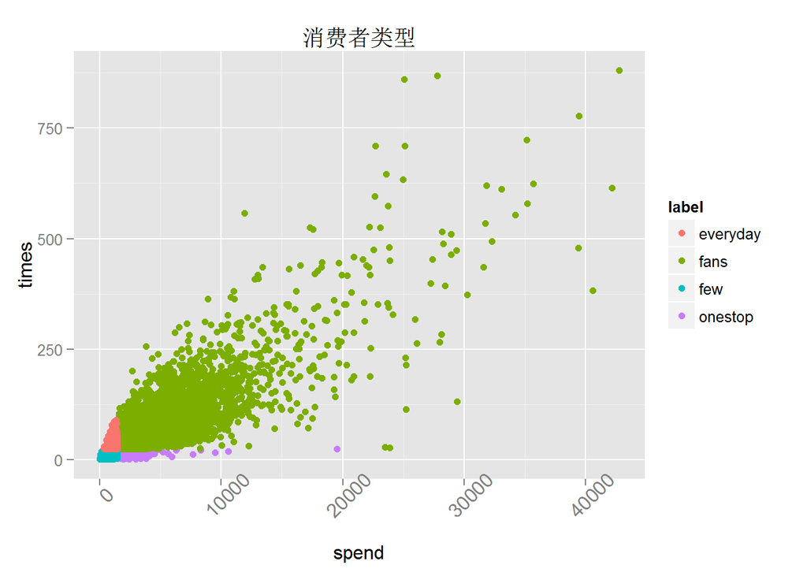

此图我们把所有普通的顾客分为四个区域。 绿色的区域是2年以来消费次数大于平均消费次数，并且消费金额大于平均消费金额的顾客。我们把他们命名为粉丝。  
玫红色的区域是2年以来消费次数大于平均值，但是消费金额小于平均值的顾客。我们把他们定义为每日购买者。  
紫色的区域是2年以来消费次数小于平均值，但是消费金额大于平均值的顾客。我们把他们定义为一站式购物者。  
蓝色的区域是2年以来消费次数小于平均值，消费金额也小于平均值的顾客。我们把他们定义为散装购买者。  
从上图我们可以看出绿色的点代表了我们的忠实客户，他们有一定的消费力，他们贡献了大部分的销售额。我们应该重点研究他们的消费习惯和偏好，有针对性的进行一些促销优惠活动。

另外，我们发现了一位特殊的顾客

```
##       cust_code   spend times
## 15761  30027222 2248654 40356
```

他在2年里，一共消费40356次，金额2248654元，经常一天内多次消费。这应该不是一个个人，而是许多没带会员卡，但却要享受优惠的许多人吧。这种特殊的现象应该予以关注。